# p8105_hw1_sz3319

Shiyu Zhang

2024-09-21

## Library Packages for Coding

```r
# Library necessary packages
library(ggplot2)
library(tidyverse)
```

## Problem 1

### a) Load the Dataset

```r
# Load "penguins" dataset
library(palmerpenguins)
data("penguins", package = "palmerpenguins")
```

### b) Describe **penguins** Dataset

```r
# Look at data
tail(penguins, 5)
skimr::skim(penguins)
```

The **penguins** dataset contains data on **344** observations and **8** variables.

The mean of flipper length is **200.9152047**.

The **8** important variables are: **species, island, bill_length_mm, bill_depth_mm, flipper_length_mm, body_mass_g, sex, year**:

- There are **3** factor variables(species, island, sex);
- and **5** numeric variables(bill_length_mm, bill_depth_mm, flipper_length_mm, body_mass_g, year).

### c) Creat and Save a Scatterplot

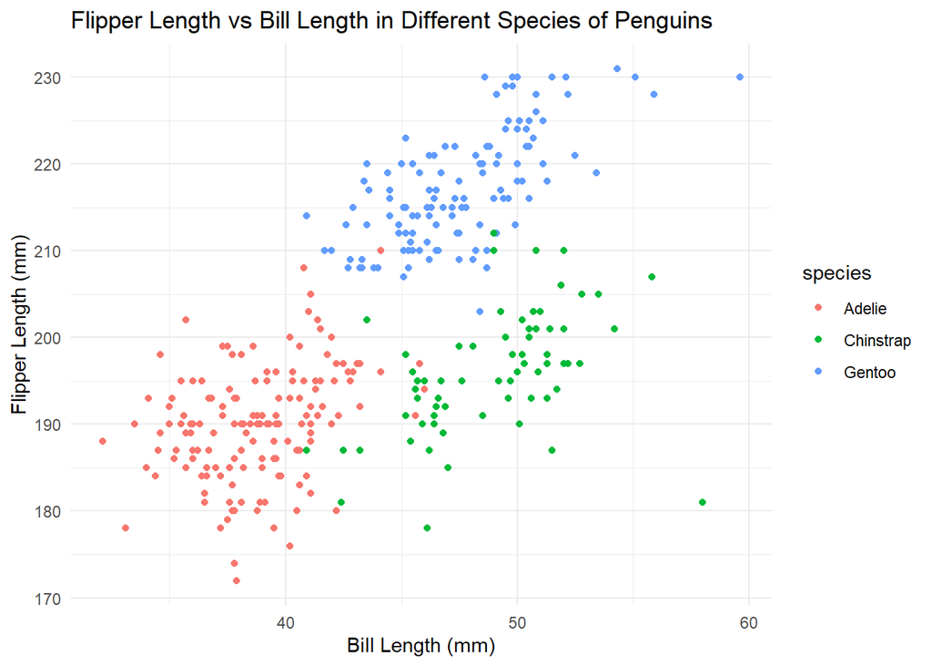

```r
library(ggplot2)
ggplot(data = penguins, aes(x = bill_length_mm, y = flipper_length_mm, color = species)) +
  geom_point(na.rm = TRUE) +
  labs(title = "Flipper Length vs Bill Length in Different Species of Penguins",
       x = "Bill Length (mm)",
       y = "Flipper Length (mm)") +
  theme_minimal()
```

```r
ggsave("penguins_scatter_plot.pdf", height = 4, width = 6)
```

## Problem 2

### a) Create the Data

```r
# For reproducibility
set.seed(1234)

# a random sample of size 10 from a standard Normal distribution
normal_sample <- rnorm(10)

# a logical vector indicating whether elements of the sample are greater than 0
logical_vector <- normal_sample > 0

# a character vector of length 10
character_vector <- sample(letters, 10, replace = TRUE)

# a factor vector of length 10, with 3 different factor “levels”
factor_vector <- factor(sample(c("A", "B", "C"), 10, replace = TRUE))
```

### b) Create a Data Frame

```r
# create data frame "df"
df <- tibble(
  normal = normal_sample,
  logical = logical_vector,
  character = character_vector,
  factor = factor_vector
)
```

### c) Calculate the mean of different variables

```r
# calculate the mean of normal sample
mean_normal <- mean(pull(df, normal))
mean_normal
```

```
## [1] -0.3831574
```

```r
#calculate the mean of
mean_logical <- mean(pull(df, logical))
mean_logical
```

```
## [1] 0.4
```

```r
#calculate the mean of
mean_character <- mean(pull(df, character))
mean_character
```

```
## [1] NA
```

```r
#calculate the mean of
mean_factor <- mean(pull(df, factor))
mean_factor
```

```
## [1] NA
```

The result shows that:

- The mean of the **normal sample** is -0.3831574.
- The mean of **logical vectors** is 0.4, for the `TRUE` is `1` and `FALSE` is `0`.
- The mean of characters and factors can’t be calculated for they are not numeric data.

### d) Convert Variables

```r
# Convert logical to numeric
logi_num <- as.numeric(pull(df, logical))
logi_num
```

```
##  [1] 0 1 1 0 1 1 0 0 0 0
```

```r
# Convert character to numeric
cha_num <- as.numeric(pull(df, character))
cha_num
```

```
##  [1] NA NA NA NA NA NA NA NA NA NA
```

```r
# Convert factor to numeric
fac_num <- as.numeric(pull(df, factor))
fac_num
```

```
##  [1] 3 3 1 2 1 2 2 3 3 3
```

The result shows that:

- The character variable **cannot** be changed into numeric variable, and the output are `NA`s.
- The factor variable can be changed in to numeric variable. The `A`, `B`, `C` are converted into `1`, `2`, `3`. However, they only randomly convert into numbers, so they may not be the real `Level`.

### The result explains that:

- The reason of the failure of calculating the mean for character and factor.
- The mean of logical vectors can be calculated. When use `as.numeric()`, `TRUE` will be converted to 1, `FALSE` will be converted to 0. As a result, the mean can be calculated.
- For the character variable, when using `as.numeric()`, all elements will return as `NA`, so there is no meaningful numeric values.
- The factor variable can converted to numeric variable, but the numbers are only **code**s, not numbers.